# Suicidio y acceso a salud mental

Javiera Preuss Araya

# Resumen

Con respecto a los recursos disponibles para salud mental durante el 2016, se realizaron distintos contrastes. En primera instancia se visualizó la cantidad de establecimientos, en donde se estimó que el 97,5% de 82 países poseen menos de un hospital psiquiátrico cada 100.000 habitantes y el 96,3% tiene menos de una unidad de salud mental en hospitales generales. Seguidamente se estudió la cantidad de psicólogos y psiquiatras en el área, en donde lamentablemente se estimó que de 104 países el 45,19 % tiene acceso a menos de un psiquiatra cada 100.000 habitantes. Con la información antes recopilada se habló de Guyana, país que pese a su baja población posee una de las mayores tasas de suicidio a nivel mundial. Esta nación tiene acceso a solo un hospital psiquiátrico y siete psiquiatras para toda la población.

# Introducción

La Organización Mundial de la Salud (OMS) reporta que cada 40 segundos una persona se suicida a nivel mundial $^{[1]}$, tasa que, a medida del transcurso de los años, ha ido aumentando y aparentemente no se observan mejorías. Cabe destacar que la cifra anteriormente mencionada no incluye a los suicidios “tentativos”, los cuales pueden llegar a ser 20 veces mayor que el suicidio consumado. Si bien algunos países han implementado nuevas intervenciones para prevenir el suicidio, estas no han sido suficientes. Una de las razones se relaciona con la calidad de los datos que estos poseen. Los países de menores ingresos tienen menos registros, lo que presenta dificultades para las organizaciones de salud al crear nuevas estrategias para reducir esta tasa.

El suicidio es un tema complejo y delicado, en el que cualquier paso en falso puede ser un error fatal. Es por ello que es inevitable cuestionarse: ¿qué es lo que esta pasando a nivel mundial con la salud mental? Hoy en día es bastante común escuchar a los jóvenes decir “me quiero morir” y normalizarlo como si fuese una broma, pero ¿y si esto no es así? ¿Qué pasaría si realmente la persona se quiere suicidar y nosotros ignoramos estas señales definitorias de vida o muerte? Si bien no todos somos personas capacitadas para estos asuntos, sí es necesario tener una idea de cómo actuar en estas situaciones, lo que da cuenta de la necesidad de más políticas públicas para que el personal especializado visualice esta realidad. En Chile, es usual escuchar que los tratamientos de salud mental tienen un costo muy elevado o que el sistema de salud está colapsado, por lo que agendar una cita es casi imposible. Entonces, una se pregunta ¿qué tan accesible es la salud mental? ¿Cuánto personal especializado existe?

Este informe tiene como objetivo comparar las tasas de suicidio de distintos países durante los años 2000, 2010, 2015 y 2016. Además, busca visibilizar la accesibilidad de los recursos de salud mental del año 2016 para cada uno de estos países. Con accesibilidad de recursos nos referimos al personal capacitado y los establecimientos destinados a salud mental.

A través de la visualización de datos se gráfica las tasas mundiales de suicidio, separando por rango etario y sexo femenino o masculino. A continuación, se analizará la accesibilidad a las instalaciones de salud mental. Luego lo contrastaremos con la cantidad de personal especializado en el área y finalmente retomaremos nuestro primer análisis de visualización y lo relacionaremos con los recursos de salud mental antes mencionados evidenciando carencias o eficiencias sistemáticas de los países.

# Metodología

En este estudio utilizaremos los datos de mental-health-and-suicide-rates provenientes de kaggle.com. Esta página contiene cuatro bases de datos. La información que recopilamos para este informe fue reorganizada y la describiremos a continuación.

La primera base de datos `tasa_suicidio` consta de cuatro variables (ver Tabla I). Contiene información de 183 países acerca de las tasas de suicidio durante los años 2000, 2010, 2015 y 2016. Esta base posee 2196 observaciones.

Tabla I: Descripción de variables tasa_suicidio.

| Variable | Tipo de variable | Descripción |
| --- | --- | --- |
| país | Categórica | Nombre del país |
| anio | Numérica | Año de tasa de suicidio (2000, 2010, 2015 o 2016) |
| sexo | Categórica | Femenino, masculino o ambos sexos |
| tasa_suicidio | Numérica | Tasa de suicidios consumados |

Tabla II: Descripción de variables tasa_suicidio_edad.

| Variable | Tipo de variable | Descripción |
| --- | --- | --- |
| país | Categórica | Nombre del país |
| sexo | Categórica | Femenino, masculino o ambos sexos |
| rango_edad | Categórica | Edades de los habitantes en intervalos de 9 años |
| tasa_suicidio | Numérica | Tasa de suicidios consumados en el año 2016 |

La tercera base `instalaciones` contiene las tasas de instalaciones de salud mental disponibles para el año 2016. Esta base tiene información de 112 países, cuyas variables describiremos en la Tabla III:

Tabla III: Descripción de variables instalaciones.

| Variable | Tipo de variable | Descripción |
| --- | --- | --- |
| país | Categórica | Nombre del país |
| hospitales_psiquiátricos | Numérica | Tasa de hospitales psiquiátricos disponibles |
| unidades_de_salud | Numérica | Tasa de unidades de salud mental en hospitales generales |

Por último, tenemos la base `personal_especializado` que contiene las tasas del personal especializado disponible para salud mental durante el 2016 de 107 países. Las variables las describiremos en la Tabla IV:

Tabla IV: Descripción de variables personal_especializado.

| Variable | Tipo de variable | Descripción |
| --- | --- | --- |
| país | Categórica | Nombre del país |
| psiquiatras | Numérica | Tasa de psiquiatras que trabajan en el sector de la salud mental |
| psicólogos | Numérica | Tasa de psicólogos que trabajan en el sector de salud mental |

Todas las tasas utilizadas en este informe están estandarizadas, es decir, son expresadas como el número de ocurrencias cada 100.000 habitantes de una determinada población.

Uno de los problemas en estas bases de datos es la existencia de datos faltantes. Es por ello que en los diversos estudios de este informe se mencionará la cantidad de países con la que se esta trabajando para evitar sesgos informativos.

# Resultados

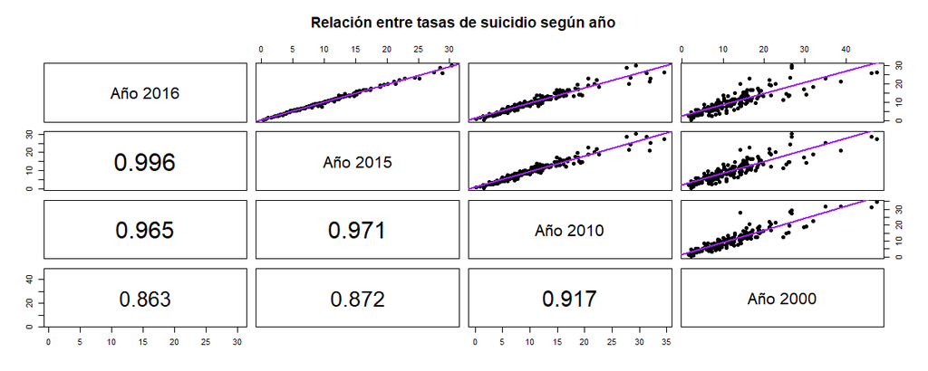

Figura 1: Relación entre tasas de suicidio con su respectiva correlación.

Ahora, enfocándonos en el año 2016, realizaremos un análisis según rango de edad, en donde se observa, a nivel mundial, un drástico aumento en la tasa de suicidio a medida que la población adquiere mayor edad (ver Figura 2).

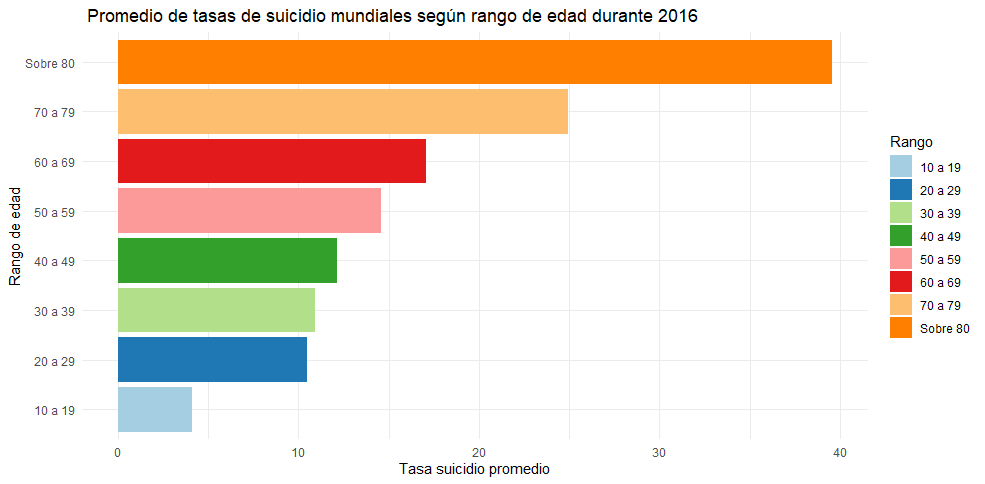

Figura 2: Tasa de suicidio promedio durante el 2016 para distintos rangos etarios.

Si bien, se visualiza un gran aumento de la tasa de suicidio para personas cuya edad está sobre 80 años, según los datos recopilados por Our World In Data, esta no es la mayor causa de muerte para este rango, si no que lo son las enfermedades cardiovasculares, cánceres y/o enfermedades respiratorias$^{[2]}$. A pesar de ello, estos niveles si son de gran importancia y como sociedad debemos preocuparnos de aquello.

Dado que el promedio es sensible a los puntos extremos, se visualizará lo que ocurre en América del Sur ¿obtendremos los mismos resultados?

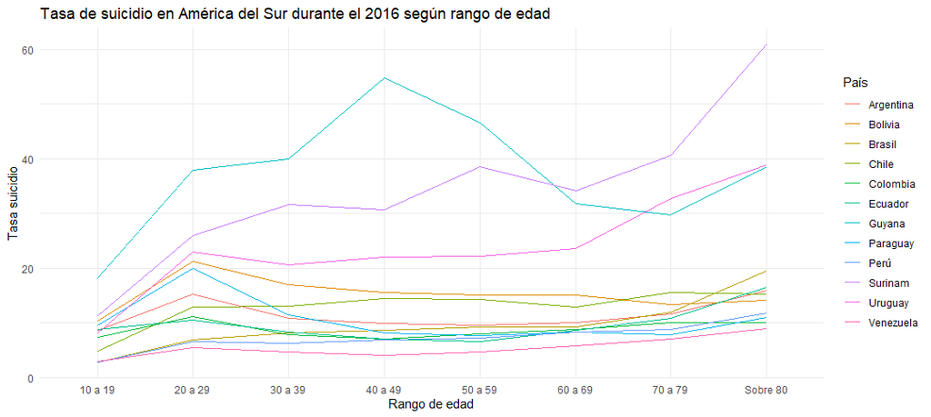

Figura 3: Gráfico de líneas América del Sur.

En la Figura 3, se observa un alza en las tasas para el rango entre 20 y 29 años, luego, en general, estas lineas tienden a disminuir levemente para así, volver a tener un alza desde los 70 años de edad alcanzando un máximo, para la mayoría de los países, en el rango sobre 80 años. Si se realizará un estudio por promedio para esta región, el país Guyana (color celeste oscuro que inicia su tasa de suicidio con un valor cercano a 20) afectaría a la estimación por tener una tasa de suicidio aproximadamente del doble que los demás países. Entonces, para los países de América del Sur, los rangos etarios con mayor tasa de suicidio son de 20 a 29 y sobre 80.

Hasta el momento hemos analizado a la totalidad de la población y se ha distinguido por rango etario, pero ¿qué pasaría si se realizara un análisis separando por la variable “sexo”? ¿Qué tan diferente será la tendencia? Para esta visualización se iniciará con la Figura 4. En donde nos enfocaremos en el año 2016 con la presencia de 183 países.

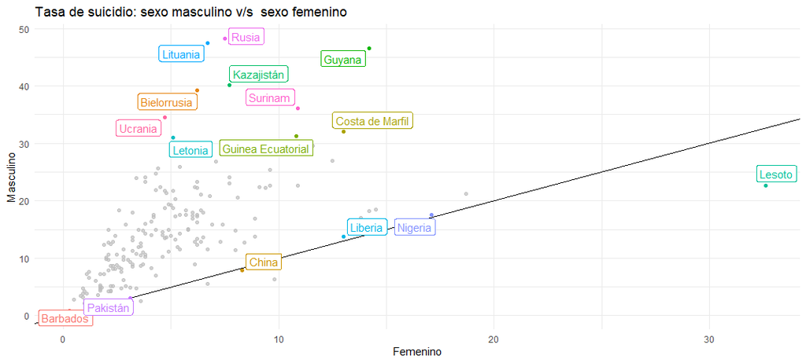

Figura 4: Comparación entre tasas de suicidio masculina y femenina.

Notemos que en la Figura 4 la concentración de las observaciones está sobre la recta. Esto nos indica que las personas de sexo masculino tienen una mayor tendencia al suicidio que las personas de sexo femenino. Además, si nos fijamos en los largos de los ejes, la tasa de suicidio para el sexo masculino duplica a los de sexo femenino en casi todos los países. Este resultado es bastante sorprendente, recordemos que a nivel mundial existen más personas de sexo femenino que de sexo masculino por lo que se esperaría una mayor tasa de suicidios para el sexo femenino. Una de las posibles razones de la gran variación de tasas es el ambiente sociocultural en el cual nos encontramos, y la asignación que los hombres se han puesto a si mismos en esta.

Ahora, veamos que pasa si relacionamos nuestro estudio por sexo y el que realizamos anteriormente con rango de edad. Para ello nos enfocaremos en las tasas de suicidio del año 2016 para Chile.

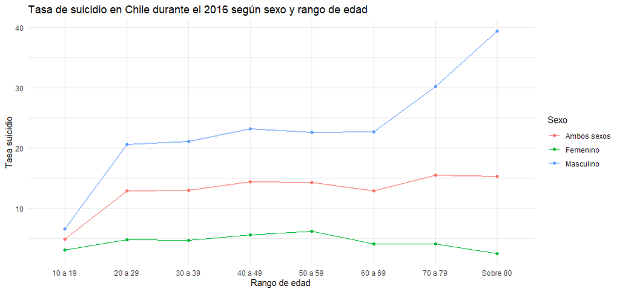

Figura 5: Tasa de suicidio v/s rango etario en Chile distinguiendo por sexo.

En la Figura 5, podemos apreciar que las personas de sexo masculino tienden más a consumar este hecho, en cambio, las personas de sexo femenino, poseen tasas notablemente menores. Además, se observa que, en el caso masculino, existe un gran alza desde los 70 años, pero en el caso femenino, hay una disminución de muertes debido al suicidio en aquel intervalo. Ahora de forma global para ambos sexos se presenta un aumento en la tasa de suicidios desde los 70 años de edad.

Entonces si contrastamos esta información con nuestros análisis anteriores, podemos apreciar que los resultados obtenidos concuerdan con lo que hemos descrito. Es por ello que podemos afirmar que, aparentemente, no existe un cambio de asociación entre las variables cuando analizamos el efecto de otra variable en particular.

Ahora hablando acerca de las instalaciones disponibles para salud mental en cada país, nos referiremos a la cantidad de hospitales psiquiátricos existentes y las unidades médicas en los hospitales generales. Es interesante tener una noción de cuantos establecimientos y lugares especializados existen. Es por ello que para esta visualización iniciaremos con un gráfico de dispersión para 82 países en donde contrastaremos ambas variables.

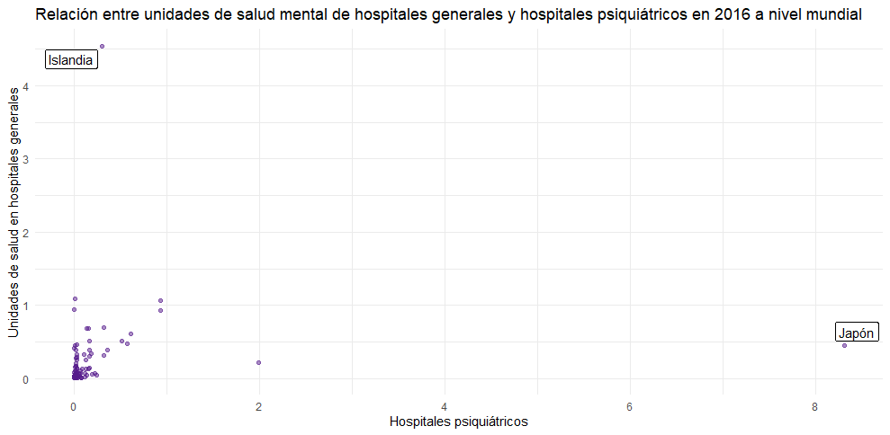

Figura 6: Gráfico de dispersión de las variables unidades de salud en hospitales generales y hospitales psiquiátricos.

De la Figura 6 podemos sacar dos conclusiones, la primera es que los países Japón e Islandia poseen tasas muy altas de hospitales psiquiátricos y unidades de salud mental en comparación a los 80 países restantes. La segunda conclusión es que la mayoría de los países posee menos de un establecimiento cada 100.000 habitantes. Para que esta última afirmación sea más clara, en la Figura 7 podemos apreciar un acercamiento a esta zona.

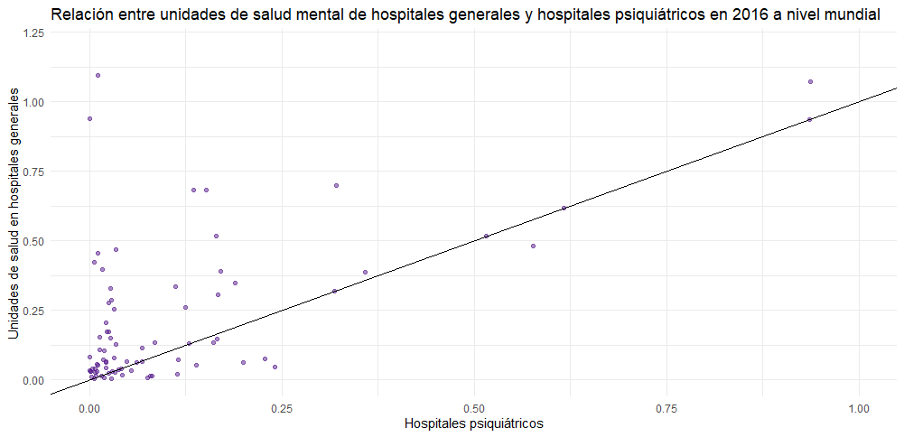

Figura 7: Gráfico de dispersión con una recta de pendiente 1 para comparar las variables.

En el gráfico anterior se visualiza que, en general, existe una mayor tasa de unidades de salud en hospitales generales que hospitales psiquiátricos. Pero que exista una mayor tasa de unidades de salud no implica que atiendan a más habitantes, al hablar de “establecimientos” nos referimos a la cantidad de edificaciones destinadas a un sector determinado. Es por esto que, a pesar de tener una mayor tasa, se esperaría que los hospitales psiquiátricos atendieran a más personas. Volviendo a la Figura 7, cabe destacar que los países ubicados en la recta nos indican que tienen una tasa para ambos establecimientos sumamente parecidas.

Con esta información podemos estimar que el 97,5% de los 82 países poseen menos de un hospital psiquiátrico y que el 96,3% tiene menos de una unidad de salud mental en hospitales generales cada 100.000 habitantes.

Una gran pregunta que surge al realizar estos análisis es ¿qué pasa con el personal especializado? ¿Alcanza para toda la población? Para este estudio contamos con una base de datos de 107 países durante el 2016.

Uno de los personales especializados más importantes en esta área son los profesionales de psiquiatría y psicología, dado que estos son los que realizan los diagnósticos de trastornos mentales de los habitantes. Es por esto que es de vital importancia tener una noción de cuantos profesionales hay disponibles, en la Figura 8 podemos apreciar un gráfico de dispersión con las variables “psiquiatras” y “psicólogos”.

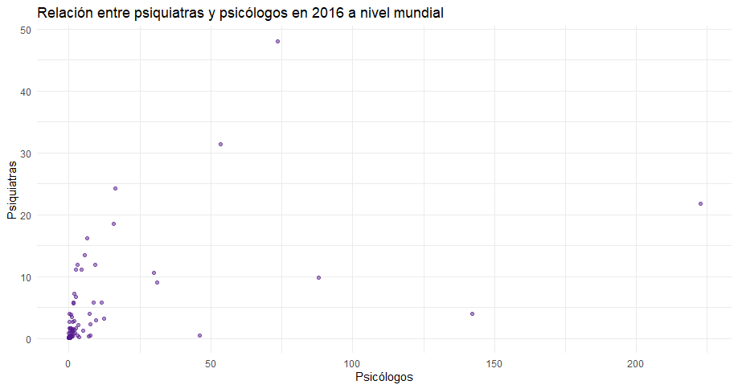

Figura 8: Comparación entre tasas de psiquiatras y psicólogos.

En esta gráfica (Fig. 8) podemos ver que en el sector inferior izquierdo, existe una gran concentración de datos, por lo que, en general, la cantidad de psicólogos y psiquiatras disponibles son bastante bajos. Además, cabe destacar que la escala del eje x “Psicólogos” es cuatro veces mayor que la escala del eje y “Psiquiatras”, esto nos indica que existe una mayor cantidad de psicólogos que de psiquiatras ¿por qué es importante mencionar esto? Porque de 104 países, el 45,19 % tiene acceso a menos de un psiquiatra cada 100.000 habitantes, cifra alarmante pues debilita a los equipos dedicados a salud mental.

Ahora, retomando nuestra comparación, notemos que, en la Figura 8, tenemos al menos tres puntos extremos en el costado inferior derecho y dos en el costado superior izquierdo, estos puntos nos indican una mayor cantidad de psicólogos o psiquiatras cada 100.000 habitantes en una determinada zona.

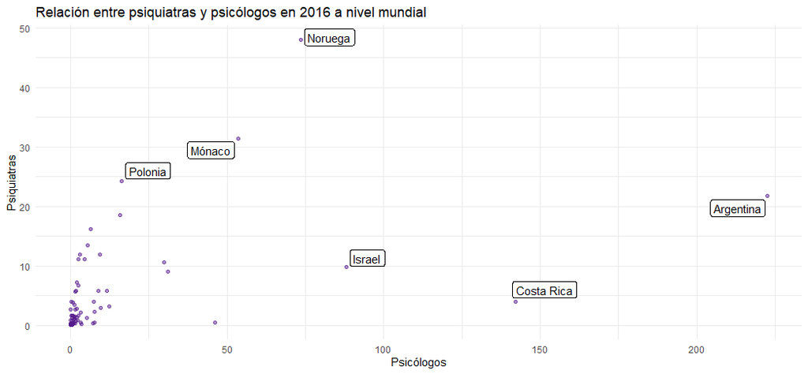

Figura 9: Relación entre psicólogos y psiquiatras identificando países con mayor tasa.

En la Figura 9, hemos identificado el país de estos puntos de interés, a los cuales analizaremos las tasas de suicidio según rango etario.

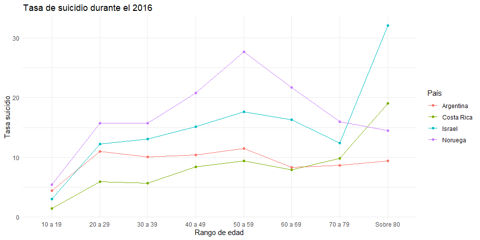

Figura 10: Tasa de suicidio según rango etario para países con mayor cantidad de personal especializado

¿Qué tan diferente será la tasa de suicidio si comparamos los países con mayor cantidad de psicólogos y psiquiatras con los de menor cantidad del personal? En la Figura 11 podemos apreciar esta comparación.

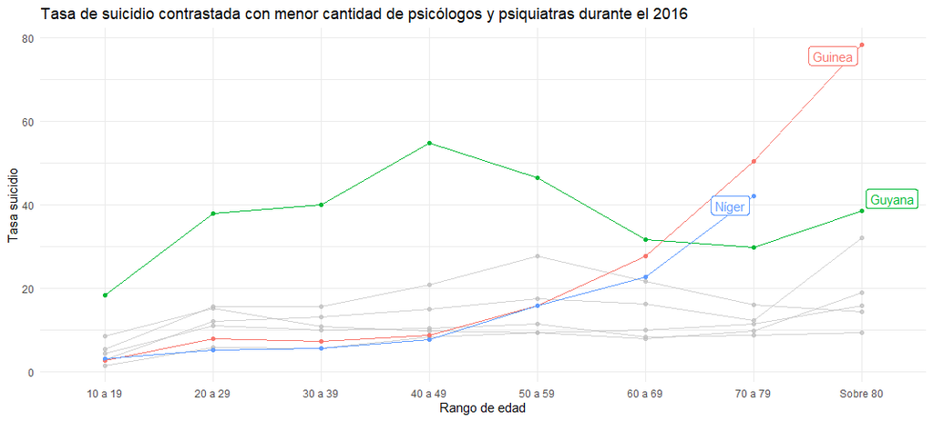

Figura 11: Comparación de tasas de suicidio para países con valores extremos de psicólogos y psiquiatras.

Es bastante difícil inferir por qué las personas se suicidan, pero si podemos afirmar que tener accesibilidad a establecimientos hospitalarios o personal especializado es de gran ayuda. Anteriormente, mencionamos a Guyana, este país de pocos habitantes que posee sólo un hospital psiquiátrico y siete psiquiatras para toda la población, lo cual no da abasto para disminuir esta tasa.

# Conclusión

Como se mencionó anteriormente uno de los principales objetivos de este informe es mostrar e informar sobre este complicado tema. Si bien las bases de datos recopiladas no estaban del todo completas de igual forma pudimos rescatar información valiosa que nos permitió estudiar estos hechos.

Frente a la información recaudada, vimos que las personas de sexo masculino tienden más a suicidarse que las de sexo femenino. Una explicación que se da para esta tendencia es la cultura en la que vivimos, en donde los hombres con su rol de superioridad, reprimen sus sentimientos y problemas llegando su punto máximo, el suicidio. Es interesante contrastar que las mujeres tienden más a tener suicidios no consumados, ya que la violencia con la que se ejerce este hecho es distinta $^{[3]}$.

Ahora hablando de los establecimientos de salud mental, se calculó que de 82 países, el 96,3% tiene menos de una unidad de salud mental en hospitales generales cada 100.000 habitantes. Esta cifra puede sonar alarmante, pero recodemos que existen muchos establecimientos que no son hospitales que se dedican a la atención mental y estos no fueron considerados para este análisis. es por ello que para tener una mejor relación causal entre variables se debe contrastar la información obtenida con otra base de datos. Por otro lado, tenemos a los hospitales psiquiátricos en donde el 97,5% de 82 países posee menos de un hospital psiquiátrico cada 100.000 habitantes. Esta cifra si es alarmante para países pequeños como Guyana, ya que, tal como mencionamos en la sección anterior, cuentan con solo un hospital psiquiátrico para todo el país, lo que evidencia las pocas políticas públicas en relación a salud mental.

Los recursos destinados hacia salud mental son sumamente bajos, según un estudio reciente de la Organización Panamericana de la Salud (OPS) reporta que solo el 2% del presupuesto de salud anual es destinado a salud mental $^{[4]}$, por lo que las nuevas herramientas, planificaciones y servicios que se deseen brindar estarán estancados debido a la poca ayuda monetaria en el área. Es por esto que es necesario crear nuevas políticas en las naciones, que puedan asegurar un mejor acceso a salud mental y que estos se mantengan con el tiempo. La importancia de estos lugares o “sitios seguros” nos ayudarán como sociedad a poder continuar avanzando, brindando una luz alternativa que no está al final del túnel.

Nunca esta demás recordar que si estas pasando por un mal momento y no tienes con quien hablar al respecto, no dudes en contactar a los canales de ayuda. En Chile puedes contactarte con Salud Responde llamando al: 600 360 7777. Tú vida **si** es importante.

# Referencias

[1]: Organización Mundial de la Salud (2019). *Cada 40 segundos se suicida una persona*. [on line] en: https://www.who.int/es/news/item/09-09-2019-suicide-one-person-dies-every-40-seconds

[2]: Our World in Data (2018). *Causes Of Deaths For People Who Were 70 Years And Older*. [on line] en: https://ourworldindata.org/grapher/causes-of-death-in-70-year-olds?time=2016

[3]: BBC News Mundo (2019). *¿Por qué hay más hombres víctimas de suicidio aunque más mujeres lo intentan?* [on line] en: https://www.bbc.com/mundo/vert-fut-47694296

[4]: Pan American Health Organization / World Health Organization (2019). *OPS insta a aumentar la inversión en salud mental*. [on line] en: https://www.paho.org/hq/index.php?option=com_content&view=article&id=14999:mental-health-spending-must-increase-in-order-to-meet-current-needs-in-the-americas&Itemid=1926&lang=es